# Final Project

Lauryn Pavlik

# Background of The Data

The data set that is being used in this analysis is taken from data.gov. This set evolved from math benchmark data in New York. It contains information such as average score, number of participants, how many students scored in each category, and the percent of students in each category. Level one is the lowest score range and level four is the highest. This data is collected from 32 districts and six grade levels over the course of six years.

## Clean Environment and Load Packages

```r
# Clean up workspace environment
rm(list = ls())
# All packages used for the project
library(tidyr)
library(dplyr)
library(ggplot2)
library(rpart.plot)
library(rpart)
library(readr)
```

## Import Data

```r
# Get data
New_york <- read_csv("final decision.csv")
# View top of the data table
head(New_york)
```

| District | Grade | Year | Category | Number Tested | Mean Scale Score | Level 1 # | Level 1 % | Level 2 # | Level 2 % | Level 3 # | Level 3 % | Level 4 # | Level 4 % | Level 3+4 # | Level 3+4 % |
| --- | --- | --- | --- | --- | --- | --- | --- | --- | --- | --- | --- | --- | --- | --- | --- |
| 1 | 3 | 2006 | Female | 496 | 675 | 34 | 6.9 | 96 | 19.4 | 252 | 50.8 | 114 | 23.0 | 366 | 73.8 |
| 1 | 3 | 2006 | Male | 441 | 672 | 39 | 8.8 | 74 | 16.8 | 232 | 52.6 | 96 | 21.8 | 328 | 74.4 |
| 1 | 3 | 2007 | Female | 406 | 681 | 23 | 5.7 | 35 | 8.6 | 248 | 61.1 | 100 | 24.6 | 348 | 85.7 |
| 1 | 3 | 2007 | Male | 413 | 678 | 24 | 5.8 | 49 | 11.9 | 250 | 60.5 | 90 | 21.8 | 340 | 82.3 |
| 1 | 3 | 2008 | Female | 407 | 686 | 8 | 2.0 | 42 | 10.3 | 256 | 62.9 | 101 | 24.8 | 357 | 87.7 |
| 1 | 3 | 2008 | Male | 437 | 687 | 8 | 1.8 | 47 | 10.8 | 271 | 62.0 | 111 | 25.4 | 382 | 87.4 |

Here the table is not yet tidy because all variable names need to be editied to fit the code style.

## Inspect Bottom of Data Table

```r
# View last six rows
tail(New_york)
```

| District | Grade | Year | Category | Number Tested | Mean Scale Score | Level 1 # | Level 1 % | Level 2 # | Level 2 % | Level 3 # | Level 3 % | Level 4 # | Level 4 % | Level 3+4 # | Level 3+4 % |
| --- | --- | --- | --- | --- | --- | --- | --- | --- | --- | --- | --- | --- | --- | --- | --- |
| 32 | All Grades | 2009 | Female | 4222 | 675 | 132 | 3.1 | 651 | 15.4 | 2640 | 62.5 | 799 | 18.9 | 3439 | 81.5 |
| 32 | All Grades | 2009 | Male | 4282 | 672 | 204 | 4.8 | 764 | 17.8 | 2593 | 60.6 | 721 | 16.8 | 3314 | 77.4 |
| 32 | All Grades | 2010 | Female | 4145 | 673 | 521 | 12.6 | 1611 | 38.9 | 1379 | 33.3 | 634 | 15.3 | 2013 | 48.6 |
| 32 | All Grades | 2010 | Male | 4363 | 670 | 666 | 15.3 | 1818 | 41.7 | 1292 | 29.6 | 587 | 13.5 | 1879 | 43.1 |
| 32 | All Grades | 2011 | Female | 4041 | 673 | 476 | 11.8 | 1643 | 40.7 | 1414 | 35.0 | 508 | 12.6 | 1922 | 47.6 |
| 32 | All Grades | 2011 | Male | 4173 | 670 | 592 | 14.2 | 1695 | 40.6 | 1417 | 34.0 | 469 | 11.2 | 1886 | 45.2 |

By viewing the last six rows of the data table, one can see that the districts extend all the way to 32 and the year goes to 2011. Although, the data for the Grade variable does not contain a single grade level for each case. This is one of the many errors that will need tidying.

## Fix Data Table

```r
# Rename the variables to accommodate style conventions
Ny_data <-
New_york %>%
 dplyr:: filter(Grade != "All Grades") %>%
  rename(district = "District", grade = "Grade", year = "Year", avg = "Mean Scale Score", level_1 = "Level 1 #", level_1_perc = "Level 1 %", level_2 = "Level 2 #", level_2_perc = "Level 2 %", level_3 = "Level 3 #", level_3_perc = "Level 3 %", level_4 = "Level 4 #", level_4_perc = "Level 4 %", students = "Number Tested", sex = "Category")
# Remove repeated columns and non numeric inputs for quantitative variables
Ny_data$`Level 3+4 #` <- NULL
Ny_data$`Level 3+4 %` <- NULL
Ny_data %>%
  filter(grepl("All Grades", grade, ignore.case = TRUE))
```

| district | grade | year | sex | students | avg | level_1 | level_1_perc | level_2 | level_2_perc | level_3 | level_3_perc | level_4 | level_4_perc |
| --- | --- | --- | --- | --- | --- | --- | --- | --- | --- | --- | --- | --- | --- |

```r
# View data table
tail(Ny_data)
```

| district | grade | year | sex | students | avg | level_1 | level_1_perc | level_2 | level_2_perc | level_3 | level_3_perc | level_4 | level_4_perc |
| --- | --- | --- | --- | --- | --- | --- | --- | --- | --- | --- | --- | --- | --- |
| 32 | 8 | 2009 | Female | 797 | 668 | 36 | 4.5 | 168 | 21.1 | 497 | 62.4 | 96 | 12.0 |
| 32 | 8 | 2009 | Male | 737 | 658 | 59 | 8.0 | 212 | 28.8 | 410 | 55.6 | 56 | 7.6 |
| 32 | 8 | 2010 | Female | 787 | 666 | 140 | 17.8 | 323 | 41.0 | 245 | 31.1 | 79 | 10.0 |
| 32 | 8 | 2010 | Male | 813 | 659 | 174 | 21.4 | 375 | 46.1 | 217 | 26.7 | 47 | 5.8 |
| 32 | 8 | 2011 | Female | 755 | 666 | 104 | 13.8 | 330 | 43.7 | 249 | 33.0 | 72 | 9.5 |
| 32 | 8 | 2011 | Male | 782 | 663 | 108 | 13.8 | 377 | 48.2 | 249 | 31.8 | 48 | 6.1 |

By viewing the last six rows again, one can now see that the “All Grades” cases are removed and the table looks much more tidy.

## Ask Questions To Explore Data

### What is the highest average score?

```r
# Create new data table with descending average score
High <-
Ny_data %>%
  arrange(desc(avg))
# View new data table
head(High)
```

| district | grade | year | sex | students | avg | level_1 | level_1_perc | level_2 | level_2_perc | level_3 | level_3_perc | level_4 | level_4_perc |
| --- | --- | --- | --- | --- | --- | --- | --- | --- | --- | --- | --- | --- | --- |
| 26 | 4 | 2009 | Female | 774 | 724 | 0 | 0.0 | 16 | 2.1 | 191 | 24.7 | 567 | 73.3 |
| 26 | 4 | 2009 | Male | 831 | 723 | 4 | 0.5 | 10 | 1.2 | 218 | 26.2 | 599 | 72.1 |
| 26 | 3 | 2009 | Female | 788 | 721 | 0 | 0.0 | 2 | 0.3 | 327 | 41.5 | 459 | 58.2 |
| 26 | 3 | 2009 | Male | 905 | 717 | 0 | 0.0 | 7 | 0.8 | 425 | 47.0 | 473 | 52.3 |
| 26 | 3 | 2010 | Female | 762 | 717 | 11 | 1.4 | 99 | 13.0 | 247 | 32.4 | 405 | 53.1 |
| 26 | 3 | 2010 | Male | 835 | 716 | 13 | 1.6 | 98 | 11.7 | 308 | 36.9 | 416 | 49.8 |

It is observed that the highest average score is 724 points.

### What is the lowest average score?

```r
# See the last six rows of the descending table
tail(High)
```

| district | grade | year | sex | students | avg | level_1 | level_1_perc | level_2 | level_2_perc | level_3 | level_3_perc | level_4 | level_4_perc |
| --- | --- | --- | --- | --- | --- | --- | --- | --- | --- | --- | --- | --- | --- |
| 9 | 7 | 2006 | Male | 1597 | 621 | 558 | 34.9 | 647 | 40.5 | 365 | 22.9 | 27 | 1.7 |
| 7 | 7 | 2006 | Male | 856 | 620 | 283 | 33.1 | 384 | 44.9 | 181 | 21.1 | 8 | 0.9 |
| 17 | 8 | 2006 | Male | 1309 | 620 | 527 | 40.3 | 504 | 38.5 | 268 | 20.5 | 10 | 0.8 |
| 9 | 8 | 2006 | Male | 1594 | 618 | 664 | 41.7 | 645 | 40.5 | 264 | 16.6 | 21 | 1.3 |
| 7 | 8 | 2006 | Female | 776 | 617 | 318 | 41.0 | 337 | 43.4 | 117 | 15.1 | 4 | 0.5 |
| 7 | 8 | 2006 | Male | 766 | 614 | 332 | 43.3 | 315 | 41.1 | 114 | 14.9 | 5 | 0.7 |

It is observed that the lowest average score is 614 points.

### Does the number of students taking the benchmark increase the average score?

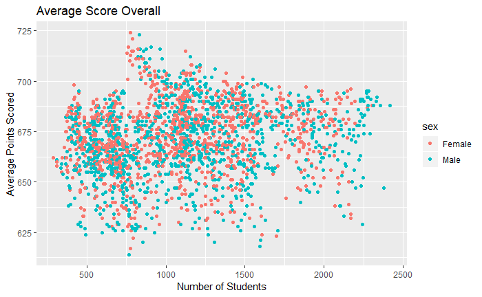

```r
# Scatterplot
Ny_data %>%
  ggplot(aes(x = students, y = avg)) +
  geom_point(aes(color = sex)) +       # Distinguish sex by color
  xlab("Number of Students") +
  ylab("Average Points Scored") +
  ggtitle("Average Score Overall")
```

It can be observed that there is a slight postive correlation, but nothing signficant to the eye.

### Add More Variables

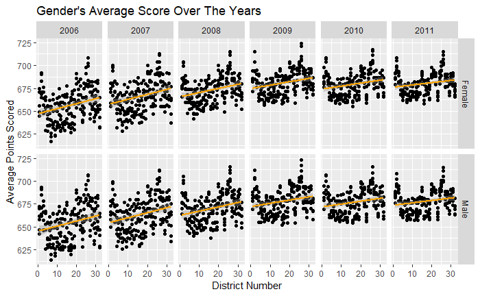

```r
# Scatterplot
Ny_data %>%
  ggplot(aes(x = district, y = avg)) +
  geom_point() +
  facet_grid(sex ~ year) +   # Seperate data by year and by sex
  geom_smooth(method = lm, color = "orange") +  # Add an orange smoother to see correlation
  xlab("District Number") +
  ylab("Average Points Scored") +
  ggtitle("Gender's Average Score Over The Years")
```

Judging from the graph, it seems that females have a slightly higher benchmark score. It is also noticeable that the scores over the districts in the more recent years have less of a postive correlation. These observations bring about a question:

## Using a hypothesis test, is there statistically significant evidence that females have higher scores than males?

Before we can move on with the test, it is safe to check and make sure there is the same total amount of males and females that have taken the benchmark. If the results are different, the test will not be valid.

### Inspect Counts

```r
Ny_data %>%
  group_by(sex) %>%
  summarise(count = n())
```

| sex | count |
| --- | --- |
| Female | 1152 |
| Male | 1152 |

There is the same amount of each sex, so the test is possible.

### First, create a data table of only female scores

```r
# Create table that only contains the first six variables of the original tidy table
No_levels <-
  Ny_data[, 1:6]

# Create table with only female scores
F_score <-
  No_levels %>%
data.frame() %>%
  spread(key = sex, value = avg) %>%   # Spread sex into seperate columns
  rename(female = "Female") %>%
  drop_na(female)   # Remove any missing values for females
# Drop the four unneeded variables
F_score$district <- NULL
F_score$grade <- NULL
F_score$students <- NULL
F_score$Male <- NULL
```

### Second, create a data table of only male scores

```r
# Create table with only male scores
M_score <-
  No_levels %>%
data.frame() %>%
  spread(key = sex, value = avg) %>%  # Again, spread sex into seperate columns
  rename(male = "Male") %>%
  drop_na(male) # Remove missing values for males
# Drop the four unneeded variables
M_score$district <- NULL
M_score$grade <- NULL
M_score$students <- NULL
M_score$Female <- NULL
```

### Third, assign vectors to mu 1 and mu 2 and run a two sample t test

```r
# Assign vectors
mu_1 <- as.vector(F_score$female)
mu_2 <- as.vector(M_score$male)
# Run test
t.test(mu_1, mu_2)
```

```
    Welch Two Sample t-test

data:  mu_1 and mu_2
t = 3.6175, df = 2294.9, p-value = 0.0003039
alternative hypothesis: true difference in means is not equal to 0
95 percent confidence interval:
 1.222677 4.117601
sample estimates:
mean of x mean of y
 672.6059  669.9358
```

From this hypothesis test, a p-value of 0.0003039 is produced. Since the p-value is very small, the null hypothesis can be rejected and there is significant evidence produced that females tend to have a greater average score on math benchmarks than males do. From this data, we are 95% confident that the average female score is about 1.22 points to 4.12 points higher than the male average score.

## Now that we know females score higher than males, it is time to question the levels of scoring

```r
# Create regression model
Avg_mod <-
  Ny_data %>%
  lm(students ~ level_1 + level_2 + level_3 + level_4, data = .)
# View model
summary(Avg_mod)
```

```
Call:
lm(formula = students ~ level_1 + level_2 + level_3 + level_4,
    data = .)

Residuals:
       Min         1Q     Median         3Q        Max
-5.736e-11 -7.000e-15  2.500e-14  5.500e-14  1.239e-11

Coefficients:
              Estimate Std. Error    t value Pr(>|t|)
(Intercept) -8.716e-13  6.870e-14 -1.269e+01   <2e-16 ***
level_1      1.000e+00  5.385e-16  1.857e+15   <2e-16 ***
level_2      1.000e+00  2.570e-16  3.891e+15   <2e-16 ***
level_3      1.000e+00  1.415e-16  7.068e+15   <2e-16 ***
level_4      1.000e+00  1.973e-16  5.068e+15   <2e-16 ***
---
Signif. codes:  0 ‘***’ 0.001 ‘**’ 0.01 ‘*’ 0.05 ‘.’ 0.1 ‘ ’ 1

Residual standard error: 1.287e-12 on 2299 degrees of freedom
Multiple R-squared:      1, Adjusted R-squared:      1
F-statistic: 7.703e+31 on 4 and 2299 DF,  p-value: < 2.2e-16
```

### Take A Different Route

```r
mean(Ny_data$level_1_perc)
```

```
[1] 9.535373
```

```r
mean(Ny_data$level_2_perc)
```

```
[1] 26.3737
```

```r
mean(Ny_data$level_3_perc)
```

```
[1] 44.06832
```

```r
mean(Ny_data$level_4_perc)
```

```
[1] 20.02431
```

By taking the mean of the percents of the different levels, it is shown that 9.54% of students score in level one, 26.37% score in level two, 44.07% score in level three and 20.02% score in level four. It can be said that most students score in the level three zone.

## Predict Average Scores Based on the Variables

Say one knows the year, grade of the students and the percent of scores coming from each level, but needs to know the actual average score for a group of students. A regression tree is a good way to predict the average score.

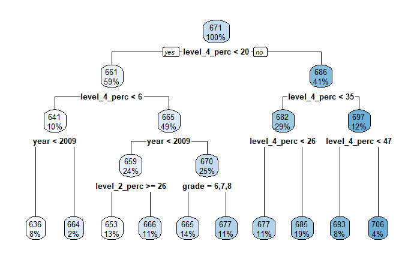

```r
# Create regression tree
Avg_tree <-
Ny_data %>%
  rpart(avg ~ . , data = .)
# Plot regression tree
rpart.plot(Avg_tree, roundint = FALSE)
```

The tree produces a model to help predict the average math benchmark score so, this would be helpful when not knowing a score for a group of students. For example, if the percent of level four scores is less than 6 and the year is 2010, we can predict the average score will be 664.